# Tugas Pertemuan 5 Metode Peramalan Deret Waktu

Muhammad Rizky Fajar (G1401211009)

# Attaching package

```r
library(ggplot2)
library(tsibble)
library(tseries)
library(MASS)
```

# Impor Data

```r
library(rio)
stas <- import("https://raw.githubusercontent.com/mhdrfajar/mpdw/main/data/saham_meta.csv")
stas = stas[,3]
stas = ts(stas)
stas
```

```
## Time Series:
## Start = 1
## End = 520
## Frequency = 1
##   [1]  32.88  30.50  29.49  24.04  22.45  22.45  20.13  19.53  19.42  22.08
##  [11]  23.37  21.98  22.59  20.75  20.48  24.25  21.69  21.48  23.93  24.68
##  [21]  28.00  28.88  28.75  28.22  27.18  28.93  31.96  32.21  31.93  32.51
##  [31]  29.29  28.75  29.08  28.12  28.68  28.64  26.90  26.28  27.80  28.10
##  [41]  27.48  27.62  29.07  28.46  27.33  26.19  24.95  24.32  24.60  25.19
##  [51]  24.98  25.06  26.00  26.78  34.88  38.49  39.32  38.50  40.63  42.26
##  [61]  44.61  45.62  47.60  51.28  51.60  51.29  54.83  54.81  52.09  50.45
##  [71]  49.57  48.84  47.21  49.39  53.50  55.89  58.58  55.65  58.96  58.57
##  [81]  59.31  63.37  64.57  67.58  70.11  71.44  71.97  72.59  69.60  67.36
##  [91]  63.91  63.18  60.58  63.65  62.28  61.35  60.89  61.48  64.30  64.36
## [101]  66.47  65.75  68.00  68.44  66.59  68.46  76.74  75.50  74.00  74.65
```

[output cut: 41 more lines]

# Analisis Data Penuh

## Plot *Time Series*

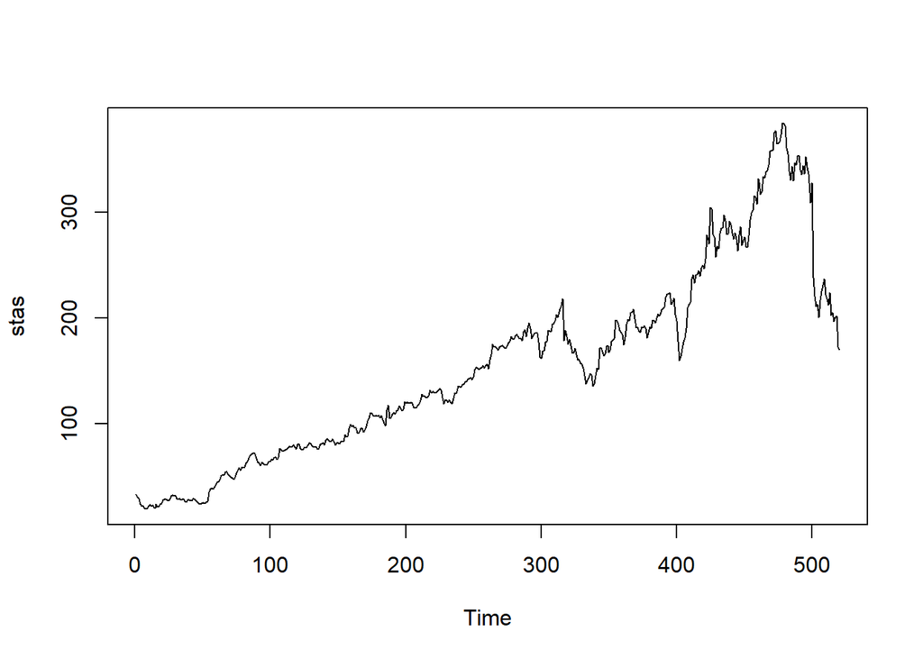

```r
ts.plot(stas)
```

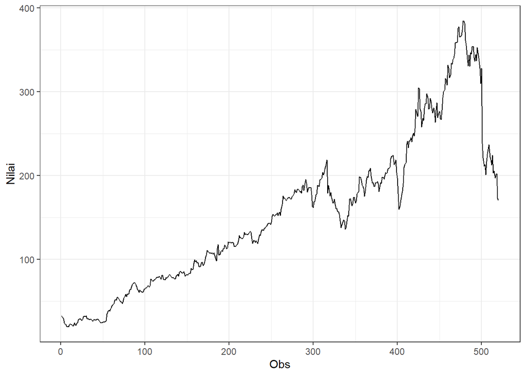

```r
plot_stas <- stas |> as_tsibble() |>
  ggplot(aes(x = index, y = value)) + geom_line() + theme_bw() +
  xlab("Obs") + ylab("Nilai")
plot_stas
```

```r
mean(stas)
```

```
## [1] 154.3096
```

Plot deret waktu di atas menunjukkan bahwa data **tidak stasioner dalam rataan** yang ditandai dengan terdapatnya pola trend pada data. Plot deret waktu tersebut juga menunjukan bahwa data **tidak stasioner dalam ragam** yang ditandai dengan lebar pita yang cenderung tidak sama.

## Plot ACF

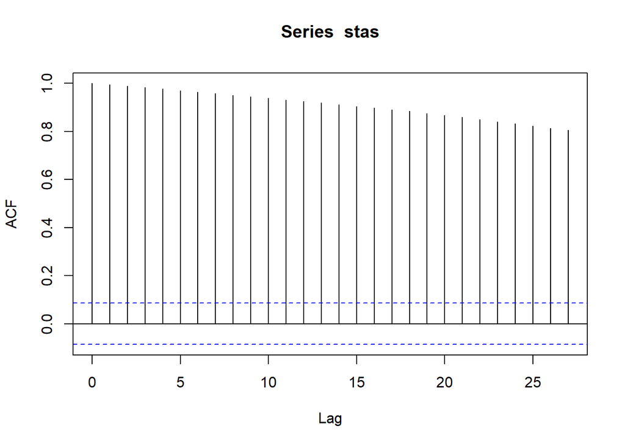

```r
acf(stas)
```

Berdasarkan plot ACF, terlihat bahwa plot ACF pada data tersebut menurun secara perlahan (*slowly tails off*). Hal tersebut mengindikasikan bahwa data **tidak stasioner dalam rataan**.

## Uji ADF

$H_0$ : Data tidak stasioner dalam rataan

$H_1$ : Data stasioner dalam rataan

```r
tseries::adf.test(stas)
```

```
##
##  Augmented Dickey-Fuller Test
##
## data:  stas
## Dickey-Fuller = -1.3922, Lag order = 8, p-value = 0.8356
## alternative hypothesis: stationary
```

Berdasarkan uji ADF tersebut, didapat *p-value* sebesar 0.8356 yang lebih besar dari taraf nyata 5% sehingga tak tolak $H_0$ dan menandakan bahwa data **tidak stasioner dalam rataan**. Hal ini sesuai dengan hasil eksplorasi menggunakan plot time series dan plot ACF.

## Plot Box-Cox

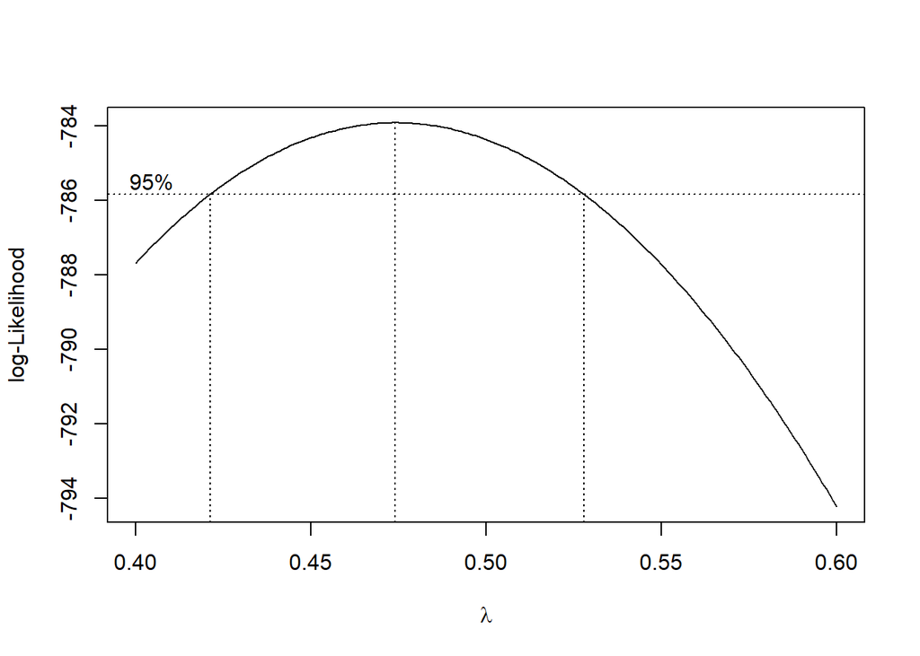

```r
index <- seq(1:520)
bc = boxcox(stas~index, lambda = seq(0.4,0.6,by=0.001))
```

```r
#Nilai Rounded Lambda
lambda <- bc$x[which.max(bc$y)]
lambda
```

```
## [1] 0.474
```

```r
#SK
bc$x[bc$y > max(bc$y) - 1/2 * qchisq(.95,1)]
```

```
##   [1] 0.422 0.423 0.424 0.425 0.426 0.427 0.428 0.429 0.430 0.431 0.432 0.433
##  [13] 0.434 0.435 0.436 0.437 0.438 0.439 0.440 0.441 0.442 0.443 0.444 0.445
##  [25] 0.446 0.447 0.448 0.449 0.450 0.451 0.452 0.453 0.454 0.455 0.456 0.457
##  [37] 0.458 0.459 0.460 0.461 0.462 0.463 0.464 0.465 0.466 0.467 0.468 0.469
##  [49] 0.470 0.471 0.472 0.473 0.474 0.475 0.476 0.477 0.478 0.479 0.480 0.481
##  [61] 0.482 0.483 0.484 0.485 0.486 0.487 0.488 0.489 0.490 0.491 0.492 0.493
##  [73] 0.494 0.495 0.496 0.497 0.498 0.499 0.500 0.501 0.502 0.503 0.504 0.505
##  [85] 0.506 0.507 0.508 0.509 0.510 0.511 0.512 0.513 0.514 0.515 0.516 0.517
##  [97] 0.518 0.519 0.520 0.521 0.522 0.523 0.524 0.525 0.526 0.527
```

Gambar di atas menunjukkan nilai *rounded value* ($\lambda$) optimum sebesar **0.474** dan pada selang kepercayaan 95% nilai memiliki batas bawah **0.422** dan batas atas **0.527**. Selang tersebut tidak memuat nilai satu sehingga dapat dikatakan bahwa data **tidak stasioner dalam ragam**.

# Analisis Data Partisi

## Bagian 1

```r
dt_stas1 <- stas[1:275] |> ts()
mean(dt_stas1)
```

```
## [1] 85.40244
```

```r
var(dt_stas1)
```

```
## [1] 1846.66
```

### Plot Time Series

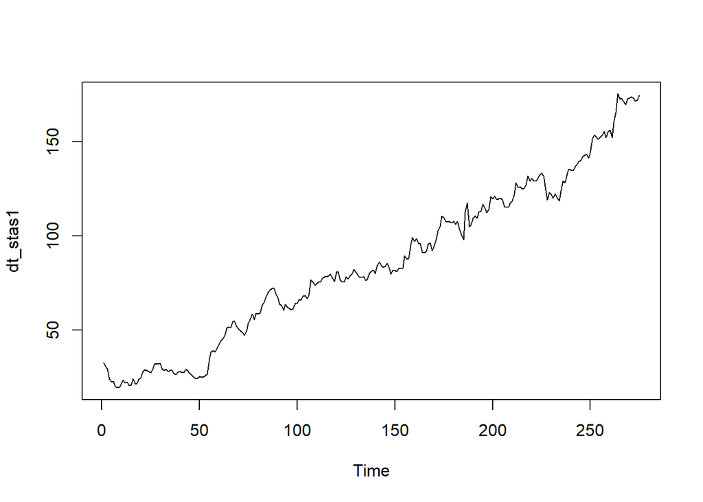

```r
ts.plot(dt_stas1)
```

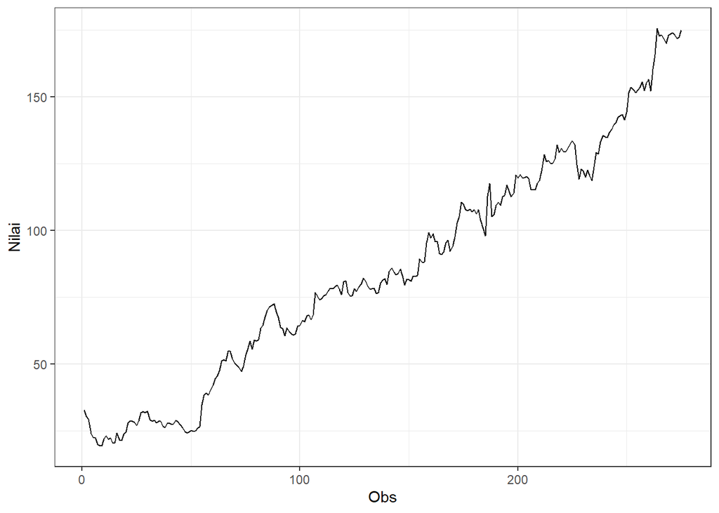

```r
dt_stas1 |> as_tsibble() |>
  ggplot(aes(x = index, y = value)) +
  geom_line() + theme_bw() +
  xlab("Obs") + ylab("Nilai")
```

Plot deret waktu di atas menunjukkan bahwa data **tidak stasioner dalam rataan** yang ditandai dengan terdapatnya pola trend pada data. Plot deret waktu tersebut juga menunjukan bahwa data **tidak stasioner dalam ragam** yang ditandai dengan lebar pita yang cenderung tidak sama.

### Plot ACF

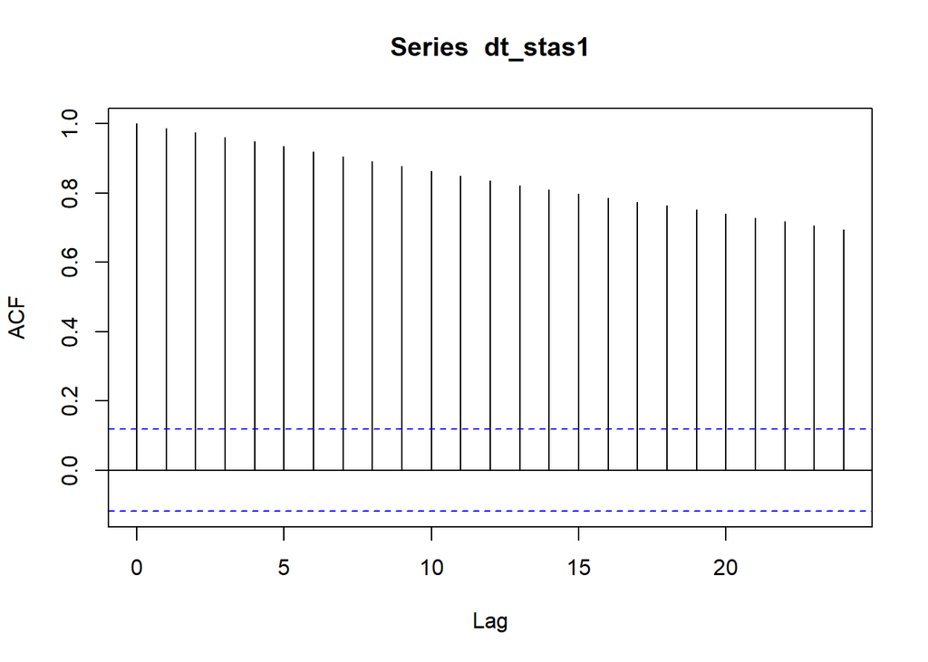

```r
acf(dt_stas1)
```

Berdasarkan plot ACF, terlihat bahwa plot ACF pada data tersebut menurun secara perlahan (*slowly tails off*). Hal tersebut mengindikasikan bahwa data **tidak stasioner dalam rataan**.

### Uji ADF

$H_0$ : Data tidak stasioner dalam rataan

$H_1$ : Data stasioner dalam rataan

```r
tseries::adf.test(dt_stas1)
```

```
##
##  Augmented Dickey-Fuller Test
##
## data:  dt_stas1
## Dickey-Fuller = -2.726, Lag order = 6, p-value = 0.2702
## alternative hypothesis: stationary
```

Berdasarkan uji ADF tersebut, didapat *p-value* sebesar 0.2702 yang lebih besar dari taraf nyata 5% sehingga tak tolak $H_0$ dan menandakan bahwa data **tidak stasioner dalam rataan**. Hal ini sesuai dengan hasil eksplorasi menggunakan plot time series dan plot ACF.

### Plot Boxcox

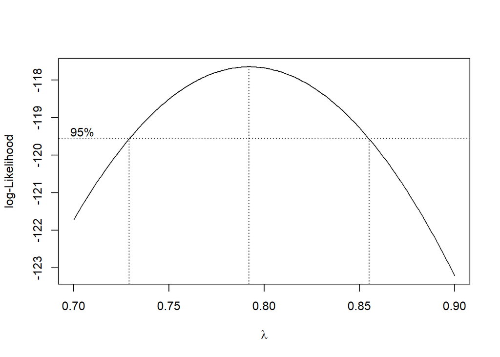

```r
index <- seq(1:275)
bc = boxcox(dt_stas1~index, lambda = seq(0.7,0.9,by=0.001))
```

```r
#Nilai Rounded Lambda
lambda <- bc$x[which.max(bc$y)]
lambda
```

```
## [1] 0.792
```

```r
#SK
bc$x[bc$y > max(bc$y) - 1/2 * qchisq(.95,1)]
```

```
##   [1] 0.730 0.731 0.732 0.733 0.734 0.735 0.736 0.737 0.738 0.739 0.740 0.741
##  [13] 0.742 0.743 0.744 0.745 0.746 0.747 0.748 0.749 0.750 0.751 0.752 0.753
##  [25] 0.754 0.755 0.756 0.757 0.758 0.759 0.760 0.761 0.762 0.763 0.764 0.765
##  [37] 0.766 0.767 0.768 0.769 0.770 0.771 0.772 0.773 0.774 0.775 0.776 0.777
##  [49] 0.778 0.779 0.780 0.781 0.782 0.783 0.784 0.785 0.786 0.787 0.788 0.789
##  [61] 0.790 0.791 0.792 0.793 0.794 0.795 0.796 0.797 0.798 0.799 0.800 0.801
##  [73] 0.802 0.803 0.804 0.805 0.806 0.807 0.808 0.809 0.810 0.811 0.812 0.813
##  [85] 0.814 0.815 0.816 0.817 0.818 0.819 0.820 0.821 0.822 0.823 0.824 0.825
##  [97] 0.826 0.827 0.828 0.829 0.830 0.831 0.832 0.833 0.834 0.835 0.836 0.837
## [109] 0.838 0.839 0.840 0.841 0.842 0.843 0.844 0.845 0.846 0.847 0.848 0.849
## [121] 0.850 0.851 0.852 0.853 0.854 0.855
```

Gambar di atas menunjukkan nilai *rounded value* ($\lambda$) optimum sebesar **0.792** dan pada selang kepercayaan 95% nilai memiliki batas bawah **0.730** dan batas atas **0.855**. Selang tersebut tidak memuat nilai satu sehingga dapat dikatakan bahwa data **tidak stasioner dalam ragam**.

## Bagian 2

```r
dt_stas2 <- stas[276:515] |> ts()
mean(dt_stas2)
```

```
## [1] 232.5521
```

```r
var(dt_stas2)
```

```
## [1] 4342.186
```

### Plot Time Series

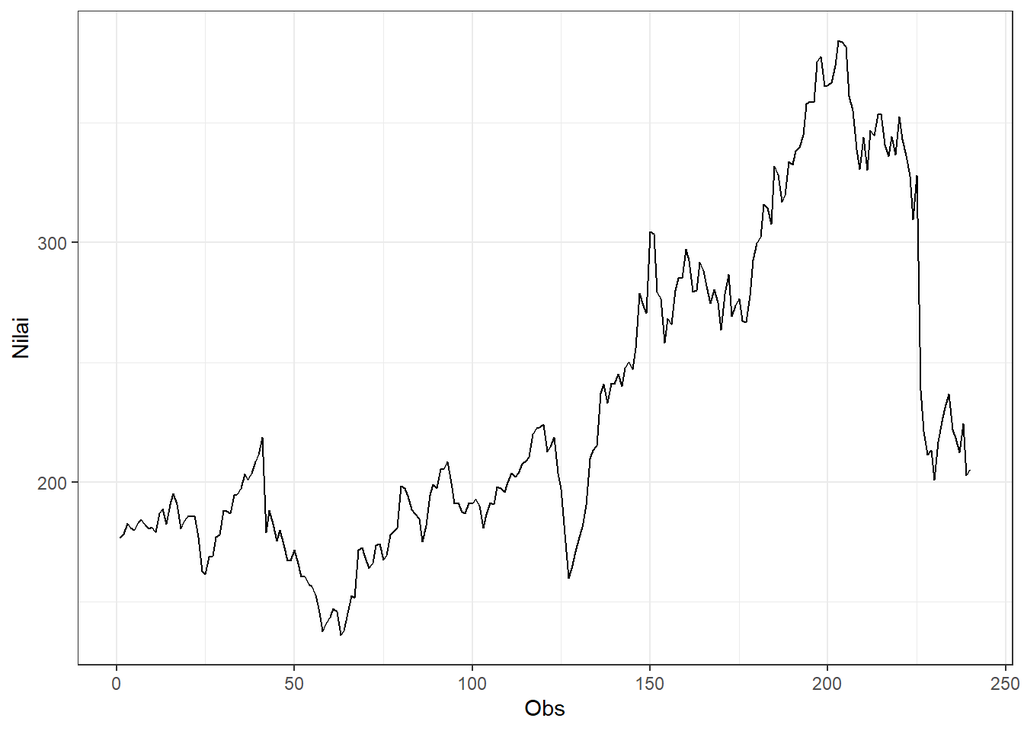

```r
dt_stas2 |> as_tsibble() |>
  ggplot(aes(x = index, y = value)) +
  geom_line() + theme_bw() +
  xlab("Obs") + ylab("Nilai")
```

Plot deret waktu di atas menunjukkan bahwa data **tidak stasioner dalam rataan** yang ditandai dengan terdapatnya pola trend pada data. Plot deret waktu tersebut juga menunjukan bahwa data **tidak stasioner dalam ragam** yang ditandai dengan lebar pita yang cenderung tidak sama.

### Plot ACF

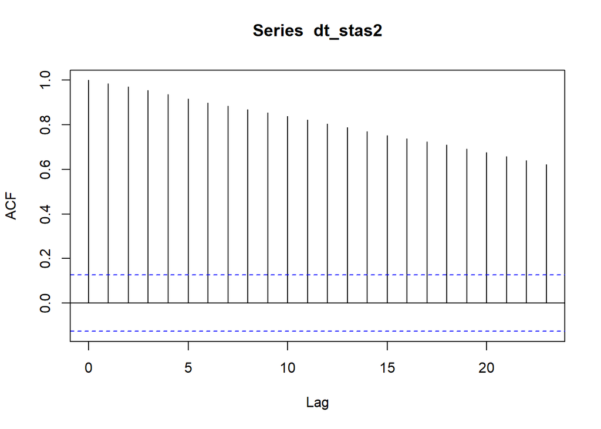

```r
acf(dt_stas2)
```

Berdasarkan plot ACF, terlihat bahwa plot ACF pada data tersebut menurun secara perlahan (*slowly tails off*). Hal tersebut mengindikasikan bahwa data **tidak stasioner dalam rataan**.

### Uji ADF

$H_0$ : Data tidak stasioner dalam rataan

$H_1$ : Data stasioner dalam rataan

```r
adf.test(dt_stas2)
```

```
##
##  Augmented Dickey-Fuller Test
##
## data:  dt_stas2
## Dickey-Fuller = -1.1416, Lag order = 6, p-value = 0.9141
## alternative hypothesis: stationary
```

Berdasarkan uji ADF tersebut, didapat *p-value* sebesar 0.9141 yang lebih besar dari taraf nyata 5% sehingga tak tolak $H_0$ dan menandakan bahwa data **tidak stasioner dalam rataan**. Hal ini sesuai dengan hasil eksplorasi menggunakan plot time series dan plot ACF.

### Plot Boxcox

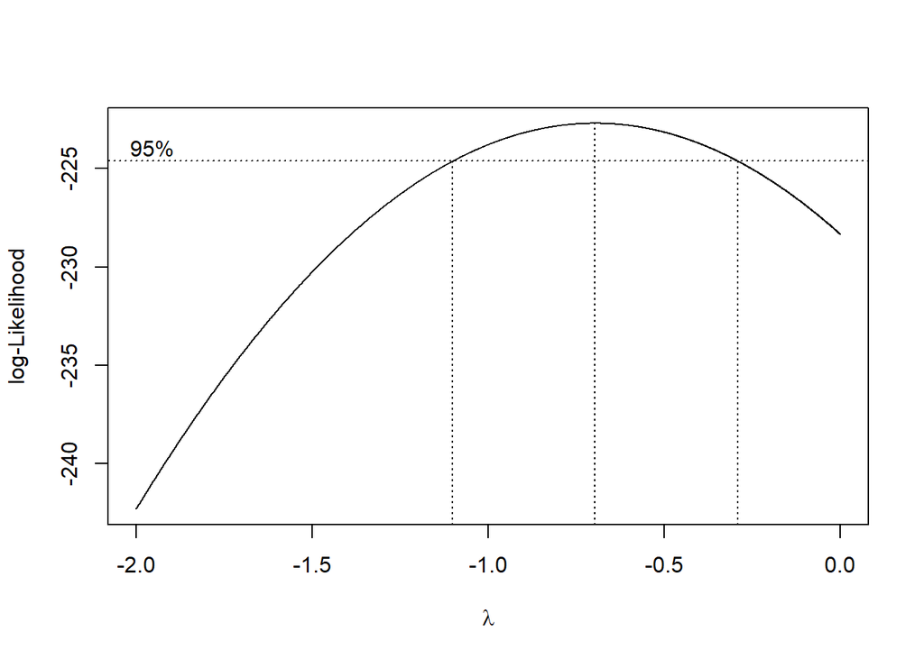

```r
index <- seq(276:515)
bc = boxcox(dt_stas2~index, lambda = seq(-2,0,by=0.001))
```

```r
#Nilai Rounded Lambda
lambda <- bc$x[which.max(bc$y)]
lambda
```

```
## [1] -0.697
```

```r
#SK
bc$x[bc$y > max(bc$y) - 1/2 * qchisq(.95,1)]
```

```
##   [1] -1.100 -1.099 -1.098 -1.097 -1.096 -1.095 -1.094 -1.093 -1.092 -1.091
##  [11] -1.090 -1.089 -1.088 -1.087 -1.086 -1.085 -1.084 -1.083 -1.082 -1.081
##  [21] -1.080 -1.079 -1.078 -1.077 -1.076 -1.075 -1.074 -1.073 -1.072 -1.071
##  [31] -1.070 -1.069 -1.068 -1.067 -1.066 -1.065 -1.064 -1.063 -1.062 -1.061
##  [41] -1.060 -1.059 -1.058 -1.057 -1.056 -1.055 -1.054 -1.053 -1.052 -1.051
##  [51] -1.050 -1.049 -1.048 -1.047 -1.046 -1.045 -1.044 -1.043 -1.042 -1.041
##  [61] -1.040 -1.039 -1.038 -1.037 -1.036 -1.035 -1.034 -1.033 -1.032 -1.031
##  [71] -1.030 -1.029 -1.028 -1.027 -1.026 -1.025 -1.024 -1.023 -1.022 -1.021
##  [81] -1.020 -1.019 -1.018 -1.017 -1.016 -1.015 -1.014 -1.013 -1.012 -1.011
##  [91] -1.010 -1.009 -1.008 -1.007 -1.006 -1.005 -1.004 -1.003 -1.002 -1.001
## [101] -1.000 -0.999 -0.998 -0.997 -0.996 -0.995 -0.994 -0.993 -0.992 -0.991
## [111] -0.990 -0.989 -0.988 -0.987 -0.986 -0.985 -0.984 -0.983 -0.982 -0.981
## [121] -0.980 -0.979 -0.978 -0.977 -0.976 -0.975 -0.974 -0.973 -0.972 -0.971
## [131] -0.970 -0.969 -0.968 -0.967 -0.966 -0.965 -0.964 -0.963 -0.962 -0.961
## [141] -0.960 -0.959 -0.958 -0.957 -0.956 -0.955 -0.954 -0.953 -0.952 -0.951
```

[output cut: 66 more lines]

Gambar di atas menunjukkan nilai *rounded value* ($\lambda$) optimum sebesar **-0.697** dan pada selang kepercayaan 95% nilai memiliki batas bawah **-1.100** dan batas atas **-0.292**. Selang tersebut tidak memuat nilai satu sehingga dapat dikatakan bahwa data **tidak stasioner dalam ragam**.